# Impact of Sentiment on Stock Performance Project

# Project Description

This project provides an analysis of the correlation between social media investor sentiment and stock performance/volatility. My project looks at a selection of stocks from the 2021 boom, and 2025 to provide a comparative analysis of how online sentiment impacted their trends. The main question I wanted to answer was: “Can investor sentiment on social media predict short-term stock price movement”? Ancillary questions I initially aimed to address were the following:

- Does social media sentiment correlate with increased volatility or trading volume in any specific stocks?
- Are there noticeable differences in how +/- sentiments impact returns?

#Dataset Description/Dictionary Stock price data was gathered using tidyquant/quantmod within R. 2021 stocks were selected from reviewing online news sources covering the 2021 boom. These stocks include:

- Gamestop and AMC

2025 Stocks were selected after perusing online financial news covering the alleged promising growth in recent “meme” stocks. These stocks include:

- Chewy, Archer Aviation, Marathon Digital holdings, MicroStrategy, and Super Micro Computer Inc.

Sentiment data was gathered using Reddit webscraping from the subreddit “wallstreetbets”.

# Load in Packages

```r
library(jsonlite)
library(tidyr)
library(tidyverse)
```

```r
library(stringr)
library(ggplot2)
library(ggthemes)
library(tidyquant)
library(quantmod)
library(dbplyr)
library(lubridate)
library(httr)
library(sentimentr)
library(ggpubr)
```

# Load in Stock Price Data from Yahoo Finance

```r
# Set stock tickers for each period
tickers_2021 <- c("GME", "AMC")
tickers_2025 <- c("CHWY", "ACHR", "MARA", "MSTR", "SMCI")

# Get daily adjusted close prices for each ticker/symbol.
tickers_all <- c(tickers_2021, tickers_2025)
stock_prices <- tq_get(tickers_all, get = "stock.prices", from = "2021-01-01", to = "2025-04-11") |>
  select(symbol, date, adjusted)
```

# Data Cleaning & Processing/Aggregation

```r
# Grouping stock_prices by ticker, and creating daily_return value
stock_prices <- stock_prices |>
  group_by(symbol) |>
  mutate(daily_return =(adjusted/ lag(adjusted)) -1)

head(stock_prices)
```

| symbol | date | adjusted | daily_return |
| --- | --- | --- | --- |
| GME | 2021-01-04 | 4.3125 | NA |
| GME | 2021-01-05 | 4.3425 | 0.00695657 |
| GME | 2021-01-06 | 4.5900 | 0.05699480 |
| GME | 2021-01-07 | 4.5200 | -0.01525058 |
| GME | 2021-01-08 | 4.4225 | -0.02157076 |
| GME | 2021-01-11 | 4.9850 | 0.12719050 |

```r
# Summary Statistics for stock_prices df
stock_prices |>
  summary()
```

```
##     symbol               date               adjusted        daily_return
##  Length:7511        Min.   :2021-01-04   Min.   :  1.630   Min.   :-0.600000
##  Class :character   1st Qu.:2022-01-26   1st Qu.:  8.671   1st Qu.:-0.029138
##  Mode  :character   Median :2023-02-21   Median : 24.300   Median :-0.001637
##                     Mean   :2023-02-19   Mean   : 45.242   Mean   : 0.002876
##                     3rd Qu.:2024-03-15   3rd Qu.: 45.355   3rd Qu.: 0.026558
##                     Max.   :2025-04-10   Max.   :625.500   Max.   : 3.012097
##                                                            NA's   :7
```

# Initializing Social Media Sentiment Data for 2021/2025 using Reddit API

```r
# Using info and credentials from created Reddit API to get access token to pull sentiment data from Reddit.
client_id <- "IHhSelyf-hxevX-Ol9szww"
client_secret <- "72y7XoQ_Iv_jB63GFCqKdjl9ah_9mQ"
username      <- "Jabari0624"
password      <- "8ZLH1d1X"

auth_response <- POST(
  url = "https://www.reddit.com/api/v1/access_token",
  authenticate(client_id, client_secret),
  body = list(grant_type = "password", username = username, password = password),
  encode = "form",
  user_agent("R sentiment project")
)

token <- content(auth_response)$access_token
```

```r
# Create function to pull Reddit posts by ticker and subreddit (2025)
get_reddit_data_2025 <- function(subreddit, token, limit = 100) {
  res <- GET(
    url = paste0("https://oauth.reddit.com/r/", subreddit, "/search"),
    add_headers(Authorization = paste("bearer", token),
                `User-Agent` = "R sentiment project"),
    query = list(
      q = "CHWY OR ACHR OR MARA OR MSTR OR SMCI",
      sort = "top",
      limit = limit,
      restrict_sr = TRUE
    )
  )

  raw <- content(res, as = "parsed")
  posts <- raw$data$children

  if (length(posts) == 0) return(data.frame())

  df <- tibble(
    title = sapply(posts, function(x) x$data$title),
    selftext = sapply(posts, function(x) x$data$selftext),
    score = sapply(posts, function(x) x$data$score),
    upvote_ratio = sapply(posts, function(x) x$data$upvote_ratio),
    created_utc = as.POSIXct(sapply(posts, function(x) x$data$created_utc), origin = "1970-01-01", tz = "UTC"),
    url = sapply(posts, function(x) x$data$url)
  )

  return(df)
}

# Use function to get posts about 2025 specified stocks.
wsb_posts_2025 <- get_reddit_data_2025("wallstreetbets", token, limit = 100)


# Get sentiment analysis from wsb_posts_2025.
wsb_posts_2025$text <- paste(wsb_posts_2025$title, wsb_posts_2025$selftext) # Merge title of the post and body text into single column
wsb_posts_2025$sentiment <- sentiment_by(wsb_posts_2025$text)$ave_sentiment # Break down text into sentences, calculate sentiment and return avg for each row of text

head(wsb_posts_2025) # View 2025 Reddit sentiment dataframe
```

| title | selftext | score | upvote_ratio | created_utc | url | text | sentiment |
| --- | --- | --- | --- | --- | --- | --- | --- |
| I made a minor miscalculation. | I held some 1370/1420 MSTR call debit spreads through close yesterday. RH exercised my long call and assigned the short. The short call assignment got voided and now if things go south, I'll be seeing… | 20308 | 0.94 | 2024-03-09 19:25:30 | https://i.redd.it/265vdytl0dnc1.png | I made a minor miscalculation. I held some 1370/1420 MSTR call debit spreads through close yesterday. RH exercised my long call and assigned the short. The short call assignment got voided and now if … | -0.148303796 |
| NVDA earnings. What's the risk? 50/50 |  | 15932 | 0.97 | 2025-02-24 17:10:32 | https://i.redd.it/kspun57ad4le1.jpeg | NVDA earnings. What's the risk? 50/50 | -0.211416801 |
| Turned 1k to 1M to now 350k. I will get back to the top. Setback for the Comeback | Welp. As many of you know I flew kinda close to the sun and had my account drop from 1M to now 350k. 100% rage tilted trades after I cut mstr. Now im thinking more clearly and entered a trade with mos… | 10266 | 0.89 | 2024-11-26 21:04:30 | https://i.redd.it/3ufhp8i39b3e1.jpeg | Turned 1k to 1M to now 350k. I will get back to the top. Setback for the Comeback Welp. As many of you know I flew kinda close to the sun and had my account drop from 1M to now 350k. 100% rage tilted … | 0.004837792 |
| The REAL Greatest Short Burn of the Century | &gt;Disclaimer from Quora: A true short squeeze is a fairly rare event. There are probably 100 predicted for every 1 that occurs.*\n\n&gt;There needs to be an unexpected positive event. This could be … | 8616 | 1.00 | 2020-09-09 01:24:14 | https://www.reddit.com/r/wallstreetbets/comments/ip6jnv/the_real_greatest_short_burn_of_the_century/ | The REAL Greatest Short Burn of the Century &gt;Disclaimer from Quora: A true short squeeze is a fairly rare event. There are probably 100 predicted for every 1 that occurs.*\n\n&gt;There needs to be … | 0.023802755 |
| +646K on $SMCI Lotto | I can post the video if me logging in for proof but I don’t see the ability to post videos | 7477 | 0.95 | 2024-10-30 14:27:50 | https://i.redd.it/zytbpjtplwxd1.jpeg | +646K on $SMCI Lotto I can post the video if me logging in for proof but I don’t see the ability to post videos | 0.100000000 |
| This week on WSB: Battle of the MSTR regards! 1 million dollar long vs 1 million dollar short. Two enter, one comes out | Place yer bets | 6289 | 0.96 | 2024-11-25 00:42:12 | https://i.redd.it/dtqwu1342y2e1.jpeg | This week on WSB: Battle of the MSTR regards! 1 million dollar long vs 1 million dollar short. Two enter, one comes out Place yer bets | -0.081374365 |

```r
# Use function to get sentiment data from 2021.
get_reddit_data_2021 <- function(subreddit, token, limit = 100) {
  res <- GET(
    url = paste0("https://oauth.reddit.com/r/", subreddit, "/search"),
    add_headers(Authorization = paste("bearer", token),
                `User-Agent` = "R sentiment project"),
    query = list(
      q = "GME OR AMC",
      sort = "top",
      limit = limit,
      restrict_sr = TRUE
    )
  )

  raw <- content(res, as = "parsed")
  posts <- raw$data$children

  if (length(posts) == 0) return(data.frame())

  df <- tibble(
    title = sapply(posts, function(x) x$data$title),
    selftext = sapply(posts, function(x) x$data$selftext),
    score = sapply(posts, function(x) x$data$score),
    upvote_ratio = sapply(posts, function(x) x$data$upvote_ratio),
    created_utc = as.POSIXct(sapply(posts, function(x) x$data$created_utc), origin = "1970-01-01", tz = "UTC"),
    url = sapply(posts, function(x) x$data$url)
  )

  return(df)
}

# Use function to get posts about 2021 specified stocks.
wsb_posts_2021 <- get_reddit_data_2021("wallstreetbets", token, limit = 100)



# Get sentiment analysis from wsb_posts_2021.
wsb_posts_2021$text <- paste(wsb_posts_2021$title, wsb_posts_2021$selftext) # Merge title of the post and body text into single column
wsb_posts_2021$sentiment <- sentiment_by(wsb_posts_2021$text)$ave_sentiment # Break down text into sentences, calculate sentiment and return avg for each row of text

head(wsb_posts_2021) # View 2021 Reddit sentiment dataframe
```

| title | selftext | score | upvote_ratio | created_utc | url | text | sentiment |
| --- | --- | --- | --- | --- | --- | --- | --- |
| GME YOLO update — Jan 28 2021 |  | 301527 | 0.98 | 2021-01-28 21:06:23 | https://i.redd.it/opzucppb15e61.png | GME YOLO update — Jan 28 2021 | 0.0000000 |
| GME YOLO month-end update — Jan 2021 |  | 265323 | 0.98 | 2021-01-29 21:04:45 | https://i.redd.it/r557em3t5ce61.png | GME YOLO month-end update — Jan 2021 | 0.0000000 |
| CLASS ACTION AGAINST ROBINHOOD. Allowing people to only sell is the definition of market manipulation. A class action must be started, Robinhood has made plenty of money off selling info about our tra… | LEAVE ROBINHOOD. They dont deserve to make money off us after the millions they caused in losses. It might take a couple of days, but send Robinhood to the ground and GME to the moon. | 228610 | 0.97 | 2021-01-28 13:49:11 | https://www.reddit.com/r/wallstreetbets/comments/l6x130/class_action_against_robinhood_allowing_people_to/ | CLASS ACTION AGAINST ROBINHOOD. Allowing people to only sell is the definition of market manipulation. A class action must be started, Robinhood has made plenty of money off selling info about our tra… | -0.1323046 |
| GME YOLO update — Feb 19 2021 |  | 224934 | 0.96 | 2021-02-19 21:05:55 | https://i.redd.it/2xswz0h11ii61.png | GME YOLO update — Feb 19 2021 | 0.0000000 |
| GME YOLO update — Jan 27 2021 --------------------------------------- guess i need 102 characters in title now |  | 219018 | 0.97 | 2021-01-27 21:15:35 | https://i.redd.it/a309gkm5yxd61.png | GME YOLO update — Jan 27 2021 --------------------------------------- guess i need 102 characters in title now | 0.0000000 |
| GME YOLO update — Feb 1 2021 |  | 217753 | 0.96 | 2021-02-01 21:07:36 | https://i.redd.it/og8ca1xskxe61.png | GME YOLO update — Feb 1 2021 | 0.0000000 |

```r
# Before joining with stock_price data, add ticker column to 2025 Sentiment dataframe.
wsb_posts_2025 <- wsb_posts_2025 |>
  mutate(ticker = map_chr(title, function(text) {
    matched <- tickers_2025[sapply(tickers_2025, function(tk) {
      str_detect(text, paste0("\\b", tk, "\\b"))
    })]
    if (length(matched) > 0) matched[1] else NA_character_
  })) %>%
  filter(!is.na(ticker))

head(wsb_posts_2025)
```

| title | selftext | score | upvote_ratio | created_utc | url | text | sentiment | ticker |
| --- | --- | --- | --- | --- | --- | --- | --- | --- |
| +646K on $SMCI Lotto | I can post the video if me logging in for proof but I don’t see the ability to post videos | 7477 | 0.95 | 2024-10-30 14:27:50 | https://i.redd.it/zytbpjtplwxd1.jpeg | +646K on $SMCI Lotto I can post the video if me logging in for proof but I don’t see the ability to post videos | 0.10000000 | SMCI |
| This week on WSB: Battle of the MSTR regards! 1 million dollar long vs 1 million dollar short. Two enter, one comes out | Place yer bets | 6289 | 0.96 | 2024-11-25 00:42:12 | https://i.redd.it/dtqwu1342y2e1.jpeg | This week on WSB: Battle of the MSTR regards! 1 million dollar long vs 1 million dollar short. Two enter, one comes out Place yer bets | -0.08137436 | MSTR |
| SMCI made me a millionaire aftermarket today… |  | 6051 | 0.94 | 2024-10-01 01:22:13 | https://i.redd.it/cy1d6e84r1sd1.jpeg | SMCI made me a millionaire aftermarket today… | 0.00000000 | SMCI |
| RIP to whoever put everything in $SMCI |  | 5893 | 0.94 | 2024-02-16 15:05:09 | https://i.redd.it/caackgs3qyic1.jpeg | RIP to whoever put everything in $SMCI | -0.09449112 | SMCI |
| $19k ===&gt; $267k in MSTR. I told you 4 months ago | I bought these calls back in June/July 2024. I wrote my DD before buying and I posted my play (check my post history) but I got mocked and laughed at. My calls went down 75% before skyrocketing 1200%.… | 5029 | 0.94 | 2024-11-23 10:15:39 | https://i.redd.it/uq4o3cclmm2e1.jpeg | $19k ===&gt; $267k in MSTR. I told you 4 months ago I bought these calls back in June/July 2024. I wrote my DD before buying and I posted my play (check my post history) but I got mocked and laughed a… | 0.01030478 | MSTR |
| Closed MARA position today - approx. 500k gain in last 30 days | Wasssup boys! I GTFO of everything today. YTD gains well over a mil. Made roughly 500k with mara options (+about 100k from riot options). See my last post for MARA positions\n\nTried to post my positi… | 4293 | 0.92 | 2023-12-21 17:03:37 | https://i.redd.it/tvjbdw6ajo7c1.jpeg | Closed MARA position today - approx. 500k gain in last 30 days Wasssup boys! I GTFO of everything today. YTD gains well over a mil. Made roughly 500k with mara options (+about 100k from riot options).… | 0.15095487 | MARA |

```r
# Summarize Setiment by ticker and date
reddit_sentiment_2025 <- wsb_posts_2025 |>
  mutate(date = as.Date(created_utc)) |>
  group_by(ticker, date) %>%
  summarise(avg_sentiment = mean(sentiment, na.rm = TRUE), .groups = "drop")

head(reddit_sentiment_2025)
```

| ticker | date | avg_sentiment |
| --- | --- | --- |
| ACHR | 2024-10-23 | 0.18899040 |
| ACHR | 2024-11-20 | 0.24907148 |
| ACHR | 2024-11-29 | 0.00000000 |
| ACHR | 2024-11-30 | 0.09345818 |
| ACHR | 2024-12-05 | -0.09888961 |
| ACHR | 2024-12-11 | 0.08976993 |

```r
# Add ticker column to 2021 Sentiment dataframe.
wsb_posts_2021 <- wsb_posts_2021 |>
  mutate(ticker = map_chr(title, function(text) {
    matched <- tickers_2021[sapply(tickers_2021, function(tk) {
      str_detect(text, paste0("\\b", tk, "\\b"))
    })]
    if (length(matched) > 0) matched[1] else NA_character_
  })) %>%
  filter(!is.na(ticker))

head(wsb_posts_2021)
```

| title | selftext | score | upvote_ratio | created_utc | url | text | sentiment | ticker |
| --- | --- | --- | --- | --- | --- | --- | --- | --- |
| GME YOLO update — Jan 28 2021 |  | 301527 | 0.98 | 2021-01-28 21:06:23 | https://i.redd.it/opzucppb15e61.png | GME YOLO update — Jan 28 2021 | 0.0000000 | GME |
| GME YOLO month-end update — Jan 2021 |  | 265323 | 0.98 | 2021-01-29 21:04:45 | https://i.redd.it/r557em3t5ce61.png | GME YOLO month-end update — Jan 2021 | 0.0000000 | GME |
| GME YOLO update — Feb 19 2021 |  | 224934 | 0.96 | 2021-02-19 21:05:55 | https://i.redd.it/2xswz0h11ii61.png | GME YOLO update — Feb 19 2021 | 0.0000000 | GME |
| GME YOLO update — Jan 27 2021 --------------------------------------- guess i need 102 characters in title now |  | 219018 | 0.97 | 2021-01-27 21:15:35 | https://i.redd.it/a309gkm5yxd61.png | GME YOLO update — Jan 27 2021 --------------------------------------- guess i need 102 characters in title now | 0.0000000 | GME |
| GME YOLO update — Feb 1 2021 |  | 217753 | 0.96 | 2021-02-01 21:07:36 | https://i.redd.it/og8ca1xskxe61.png | GME YOLO update — Feb 1 2021 | 0.0000000 | GME |
| Used some of my GME tendies to buy Nintendo Switches from Gamestop, then donated them to a Children's Hospital. Got featured on the local news and brought glory to WSB. |  | 215387 | 0.93 | 2021-01-30 02:53:40 | https://www.nbcdfw.com/news/local/north-texas-investor-uses-gamestop-gains-help-sick-children/2537134/ | Used some of my GME tendies to buy Nintendo Switches from Gamestop, then donated them to a Children's Hospital. Got featured on the local news and brought glory to WSB. | 0.1892102 | GME |

```r
# Summarize Setiment by ticker and date
reddit_sentiment_2021 <- wsb_posts_2021 |>
  mutate(date = as.Date(created_utc)) %>%
  group_by(ticker, date) %>%
  summarise(avg_sentiment = mean(sentiment, na.rm = TRUE), .groups = "drop")

head(reddit_sentiment_2021)
```

| ticker | date | avg_sentiment |
| --- | --- | --- |
| AMC | 2021-02-01 | 0.2236081 |
| AMC | 2021-02-26 | 0.1941335 |
| AMC | 2021-05-18 | -0.2500000 |
| AMC | 2021-05-26 | -0.2500000 |
| AMC | 2021-06-04 | 0.0000000 |
| GME | 2021-01-13 | 0.0000000 |

# Joining Sentiment Data with Stock Data

```r
# Left Join to merge 2021/2025 sentiment data frames with stock price data.
price_sentiment_2021 <- left_join(reddit_sentiment_2021,
                                  stock_prices,
                                  by = c("ticker" = "symbol", "date" = "date"))

price_sentiment_2025 <- left_join(reddit_sentiment_2025,
                                  stock_prices,
                                  by = c("ticker" = "symbol", "date" = "date"))

#Removing NAs
 price_sentiment_2021 <- price_sentiment_2021 |>
  drop_na()

 price_sentiment_2025 <- price_sentiment_2025 |>
   drop_na()
```

For my visualizations, I thought of adding a lag to address the question of: “Does yesterday’s wallstreetbets sentiment predict/correlate with today’s stock price performance?”

# Visualization 1: Relationship bw Lagged Sentiment and Stock Returns (2025)

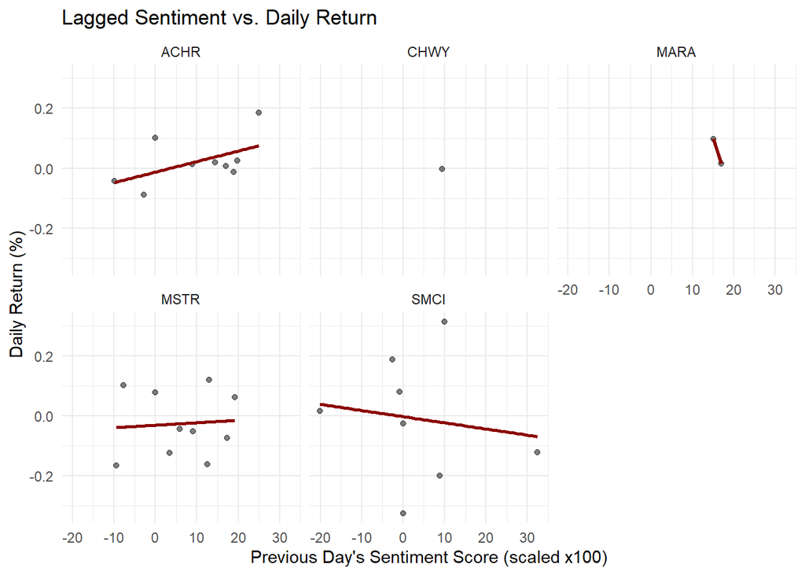

```r
lagged_df_2025 <- price_sentiment_2025 %>%
  group_by(ticker) %>%
  mutate(lagged_sentiment = lag(avg_sentiment, 1))

ggplot(lagged_df_2025, aes(x = lagged_sentiment * 100, y = daily_return)) +
  geom_point(alpha = 0.5) +
  geom_smooth(method = "lm", se = FALSE, color = "darkred") +
  facet_wrap(~ticker) +
  labs(title = "Lagged Sentiment vs. Daily Return",
       x = "Previous Day's Sentiment Score (scaled x100)",
       y = "Daily Return (%)") +
  theme_minimal()
```

2025 Lagged Results

- ACHR: Mildly positive, as sentiment increases +, stock performance seems to slightly increase
- CHWY: No notable trend line, due to little mention on Reddit.
- MARA: Negative, suggesting positive sentiment had some inverse impact on stock price performance.
- MSTR: Barely positive, suggesting sentiment had weak + impact on stock performance.
- SMCI: slightly negative

The fact that no interaction effects or controls were utilized in this regression could explain the lack of magnitude in these visualizations. Further analysis could be improved by making use of these techniques.

# Visualization 2: Relationship bw Lagged Sentiment and Stock Returns (2021)

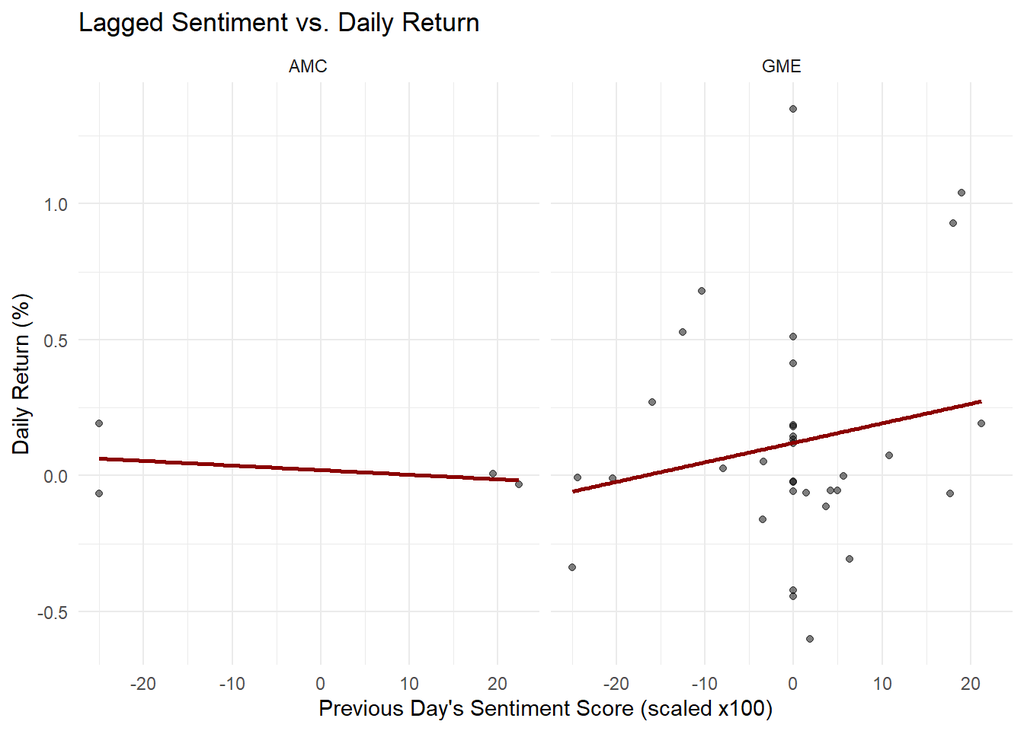

```r
lagged_df_2021 <- price_sentiment_2021 %>%
  group_by(ticker) %>%
  mutate(lagged_sentiment = lag(avg_sentiment, 1))

ggplot(lagged_df_2021, aes(x = lagged_sentiment * 100, y = daily_return)) +
  geom_point(alpha = 0.5) +
  geom_smooth(method = "lm", se = FALSE, color = "darkred") +
  facet_wrap(~ticker) +
  labs(title = "Lagged Sentiment vs. Daily Return",
       x = "Previous Day's Sentiment Score (scaled x100)",
       y = "Daily Return (%)") +
  theme_minimal()
```

2021 Lagged Results

- AMC: slightly negative, suggesting sentiment had a weak yet inverse impact on stock performance
- GME: mildly positive, sentiment posted on social media had a larger impact on stock performance

# Visualization 3: Heatmap of Correlations bw Stock Price and Lagged Sentiment by Ticker (2025)

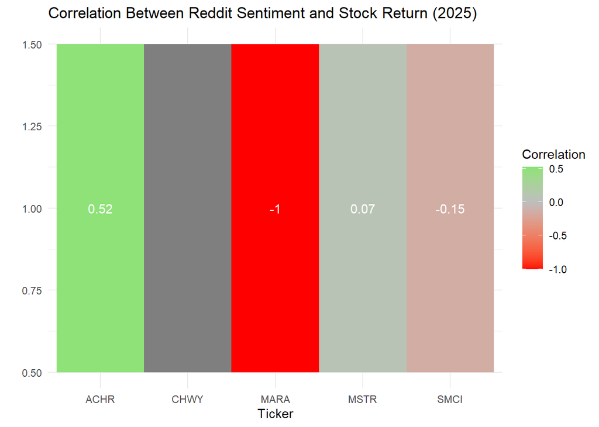

```r
cor_df_2025 <- lagged_df_2025 %>%
  group_by(ticker) %>%
  summarise(cor_sentiment_return = cor(lagged_sentiment, daily_return, use = "complete.obs"))

ggplot(cor_df_2025, aes(x = ticker, y = 1, fill = cor_sentiment_return)) +
  geom_tile() +
  geom_text(aes(label = round(cor_sentiment_return, 2)), color = "white") +
  scale_fill_gradient2(low = "red", high = "green", mid = "gray", midpoint = 0) +
  labs(title = "Correlation Between Reddit Sentiment and Stock Return (2025)",
       x = "Ticker", y = "", fill = "Correlation") +
  theme_minimal()
```

2025 Heatmap Analysis

# Visualization 4: Heatmap of Correlations bw Stock Price and Lagged Sentiment by Ticker (2021)

[figure not shown]

```r
cor_df_2021 <- lagged_df_2021 %>%
  group_by(ticker) %>%
  summarise(cor_sentiment_return = cor(lagged_sentiment, daily_return, use = "complete.obs"))

ggplot(cor_df_2021, aes(x = ticker, y = 1, fill = cor_sentiment_return)) +
  geom_tile() +
  geom_text(aes(label = round(cor_sentiment_return, 2)), color = "white") +
  scale_fill_gradient2(low = "red", high = "green", mid = "gray", midpoint = 0) +
  labs(title = "Correlation Between Reddit Sentiment and Stock Return (2025)",
       x = "Ticker", y = "", fill = "Correlation") +
  theme_minimal()
```

2021 Heatmap Analysis

- Gamestop slightly positive correlation, would have expected a higher correlation coefficient given its status as the catalyst stock.

# Regression Analysis: Relationship between Sentiment and Daily Stock Returns in 2025

```r
# Run Regression
model <- lm(daily_return ~lagged_sentiment, data = lagged_df_2025)
summary(model)
```

```
##
## Call:
## lm(formula = daily_return ~ lagged_sentiment, data = lagged_df_2025)
##
## Residuals:
##      Min       1Q   Median       3Q      Max
## -0.31892 -0.07226  0.00383  0.08780  0.31114
##
## Coefficients:
##                   Estimate Std. Error t value Pr(>|t|)
## (Intercept)      -0.007833   0.028468  -0.275    0.785
## lagged_sentiment  0.091303   0.208944   0.437    0.665
##
## Residual standard error: 0.1304 on 28 degrees of freedom
##   (5 observations deleted due to missingness)
## Multiple R-squared:  0.006773,   Adjusted R-squared:  -0.0287
## F-statistic: 0.1909 on 1 and 28 DF,  p-value: 0.6655
```

Analysis:

# Regression Analysis: Relationship between Sentiment and Daily Stock Returns in 2021

```r
# Run Regression
model_2021 <- lm(daily_return ~lagged_sentiment, data = lagged_df_2021)
summary(model_2021)
```

```
##
## Call:
## lm(formula = daily_return ~ lagged_sentiment, data = lagged_df_2021)
##
## Residuals:
##      Min       1Q   Median       3Q      Max
## -0.71927 -0.18722 -0.06272  0.07307  1.23694
##
## Coefficients:
##                  Estimate Std. Error t value Pr(>|t|)
## (Intercept)       0.11142    0.06428   1.733   0.0916 .
## lagged_sentiment  0.41696    0.50878   0.820   0.4179
## ---
## Signif. codes:  0 '***' 0.001 '**' 0.01 '*' 0.05 '.' 0.1 ' ' 1
##
## Residual standard error: 0.396 on 36 degrees of freedom
##   (2 observations deleted due to missingness)
## Multiple R-squared:  0.01831,    Adjusted R-squared:  -0.008955
## F-statistic: 0.6716 on 1 and 36 DF,  p-value: 0.4179
```

Analysis:

- Slightly improved magnitude compared to 2025
- All else equal reddit sentiment moves in a similar fashion to stock data
- Improved magnitude/lower p-value compared to 2025 regression could suggest during the 2021 boom social media sentiment played a larger role in influencing stock performance.

# Conclusion

Main limitations of this analysis were that no interaction effects or control/instrumental variables were utilized in the regressions. The addition of such factors could have improved the magnitude of the coefficient estimates, leading to more significant findings. Still, signage for the linear impact of sentiment on stock price seemed to be appropriate.